# Enhancing Educational Outcomes: Leveraging Global Data Insights

Project 3

SID 540057328

University of Sydney | DATA1001 | May 2024

# 1 Client Bio & Recommendation

**Client Bio:**

Michele Bruniges [link](https://www.oecd.org/pisa/)

- The chairman of OECD’s Programme for International Student Assessment(PISA)
- PISA assesses how well 15-year-olds can apply their knowledge and abilities in reading, math, and science to tackle real-world problems

**Recommendation:**

This report presents a detailed analysis of the relationship between average national IQ scores and a range of educational and economic indicators. Our goal is to point out the crucial elements that lead to educational success and to offer strategic recommendations for PISA. By assisting the nations which underperform in IQ in enhancing their education systems, PISA could investigate the education systems of countries that achieve high results in both IQ and PISA to understand the factors driving their success. This analysis could then be used to identify the reasons why some countries underperform. With these insights, PISA could provide recommendations to help these underperforming countries enhance their education systems.

# 2 Evidence

## 2.1 Initial Data Analysis (IDA)

Summary:

- The data came from the datasets in Kaggle,and the results released by PISA.
- The data is valid because it covers a broad spectrum of indicators that are crucial for analyzing educational systems globally.
- Possible issues include missing values in several columns such as ‘Mean years of schooling - 2021’, ‘GNI - 2021’, and partial PISA results. So the correlation between IQ and those factors cannot be examined in certain countries.
- Each row represents a country with its respective data on various indicators.
- Each column represents ranking, country names, average IQ, continent, literacy rate, nobel prizes, HDI, mean years of schooling, GNI-2021, population-2023, and total PISA results-2018.
- Data containing NA values are excluded to avoid errors.

## 2.2 Correlation between GNI and average IQ

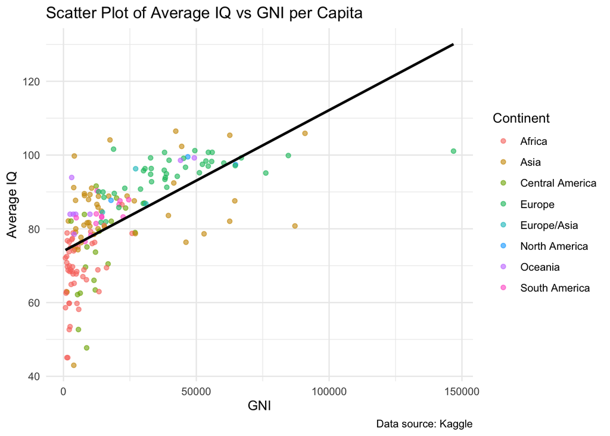

```r
setwd("/Users/jasonli/Documents/DATA 1001")
data <- read.csv("avgIQpercountry.csv")
data_clean <- subset(data, !is.na(GNI...2021))
library(ggplot2)

ggplot(data_clean, aes(x = GNI...2021, y = Average.IQ)) +
  geom_point(aes(color = Continent), alpha = 0.6) +
  geom_smooth(method = "lm", color = "black", se = FALSE) +
  labs(title = "Scatter Plot of Average IQ vs GNI per Capita",
       x = "GNI",
       y = "Average IQ",
       caption = "Data source: Kaggle") +
  theme_minimal()
```

```r
correlation_coefficient <- cor(data_clean$GNI...2021, data_clean$Average.IQ, use = "complete.obs")
print(correlation_coefficient)
```

```
## [1] 0.6348542
```

Based on the scatter plot, there is a remarkable trend where countries with higher GNI generally show higher average IQ scores compared to those with lower GNI. By calculation, the correlation coefficient is 0.6348542. This signifies that a country’s economic conditions may influence its national IQ scores. A plausible explanation for this correlation could be that better economic conditions enable greater investment in the education system, which in turn could enhance educational outcomes. Conversely, countries with bad economic condition may have limited resources to allocate toward education, potentially leading to lower average IQ scores due to unsatisfactory education system. This relationship underscores the importance of the impact of economic condition on national IQ.

## 2.3 Correlation between mean year of schooling and average IQ

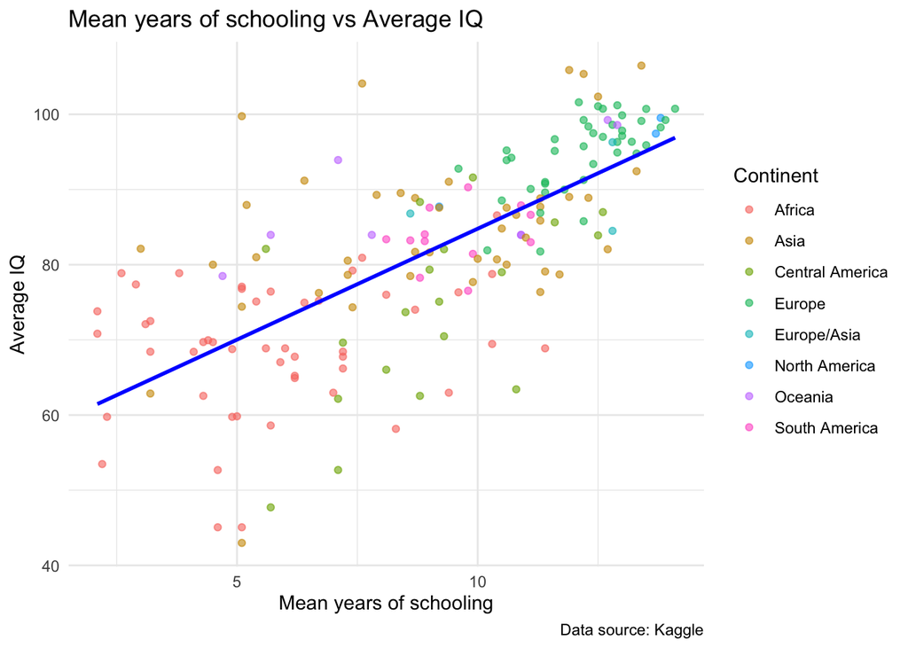

```r
setwd("/Users/jasonli/Documents/DATA 1001")
data <- read.csv("avgIQpercountry.csv")
cleaned_data <- subset(data, !is.na(Mean.years.of.schooling...2021))
library(ggplot2)

ggplot(cleaned_data, aes(x = Mean.years.of.schooling...2021, y = Average.IQ)) +
  geom_point(aes(color = Continent), alpha = 0.6) +
  geom_smooth(method = "lm", color = "blue", se = FALSE) +
  labs(title = "Mean years of schooling vs Average IQ",
       x = "Mean years of schooling",
       y = "Average IQ",
       caption = "Data source: Kaggle") +
  theme_minimal()
```

```r
correlation_coefficient <- cor(cleaned_data$Mean.years.of.schooling...2021, cleaned_data$Average.IQ, use = "complete.obs")
print(correlation_coefficient)
```

```
## [1] 0.7054428
```

According to the graph above, there is a significant relation between the mean years of schooling and average IQ as the correlation coefficient is 0.7054428 by calculation. In other words, this trend shows that more years in schooling generally lead to higher average IQ scores. Therefore, IQ can be affected by education.

## 2.4 Hypothesis Testing

For this hypothesis test:

- H0 = IQ scores do not affect PISA results
- H1 = IQ scores do affect PISA results

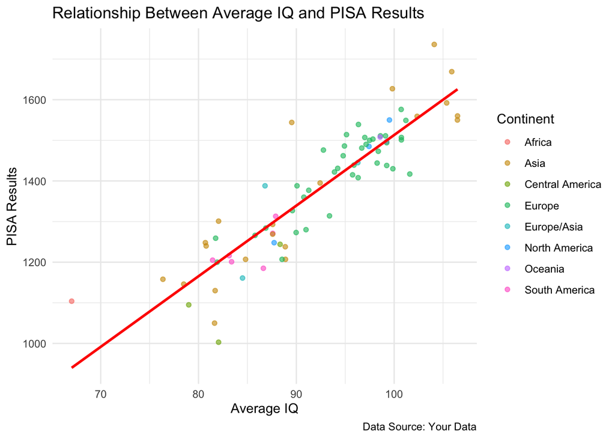

```r
setwd("/Users/jasonli/Documents/DATA 1001")
data <- read.csv("avgIQpercountry.csv")
clear_data <- subset(data, !is.na(Total.PISA.results...2018))

library(ggplot2)

ggplot(clear_data, aes(x = Average.IQ, y = Total.PISA.results...2018)) +
  geom_point(aes(color = Continent), alpha = 0.6) +
  geom_smooth(method = "lm", se = FALSE, color = "red") +
  labs(title = "Relationship Between Average IQ and PISA Results",
       x = "Average IQ",
       y = "PISA Results",
       caption = "Data Source: Your Data") +
  theme_minimal()
```

```r
correlation_coefficient <- cor(clear_data$Total.PISA.results...2018, clear_data$Average.IQ, use = "complete.obs")
print(correlation_coefficient)
```

```
## [1] 0.8957478
```

With correlation coefficient 0.8957478, it shows a strong relation between IQ scores and PISA results. Students with higher IQ scores tend to obtain higher outcomes in PISA assessment.

# 3 Acknowledgments

Style: IEEE

[1]“PISA - PISA.” https://www.oecd.org/pisa/

[2]FactsMaps, “PISA 2018 Worldwide Ranking - average score of mathematics, science and reading - FactsMaps,” FactsMaps, Dec. 09, 2023. https://factsmaps.com/pisa-2018-worldwide-ranking-average-score-of-mathematics-science-reading/

[3]“Average global IQ per country with other stats,” Kaggle, Nov. 16, 2023. https://www.kaggle.com/datasets/mlippo/average-global-iq-per-country-with-other-stats?resource=download

# 4 Appendix

## 4.1 Client Choice

I chose Michele Bruniges because I believe that there is a strong correlation between PISA and IQ scores, suggesting that a good education system can lead to higher IQ scores.

## 4.2 Statisitcal Analyses

Linear modelling was chosen to demonstrate the correlation between average IQ and other economic Indicators.

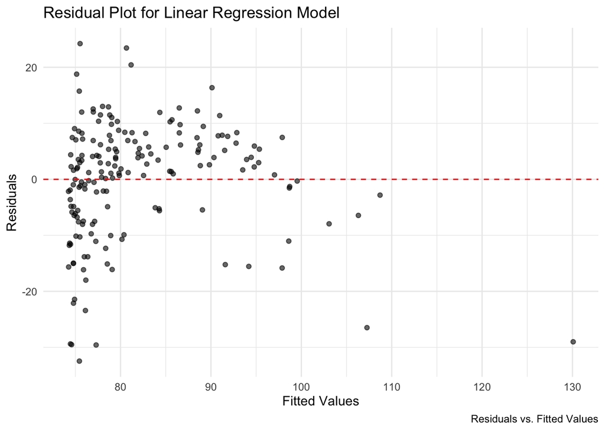

```r
model <- lm(Average.IQ ~ GNI...2021, data = data_clean)
residuals_df <- data.frame(Residuals = residuals(model), Fitted = fitted(model))
ggplot(residuals_df, aes(x = Fitted, y = Residuals)) +
  geom_point(alpha = 0.6) +
  geom_hline(yintercept = 0, linetype = "dashed", color = "red") +
  labs(title = "Residual Plot for Linear Regression Model",
       x = "Fitted Values",
       y = "Residuals",
       caption = "Residuals vs. Fitted Values") +
  theme_minimal()
```

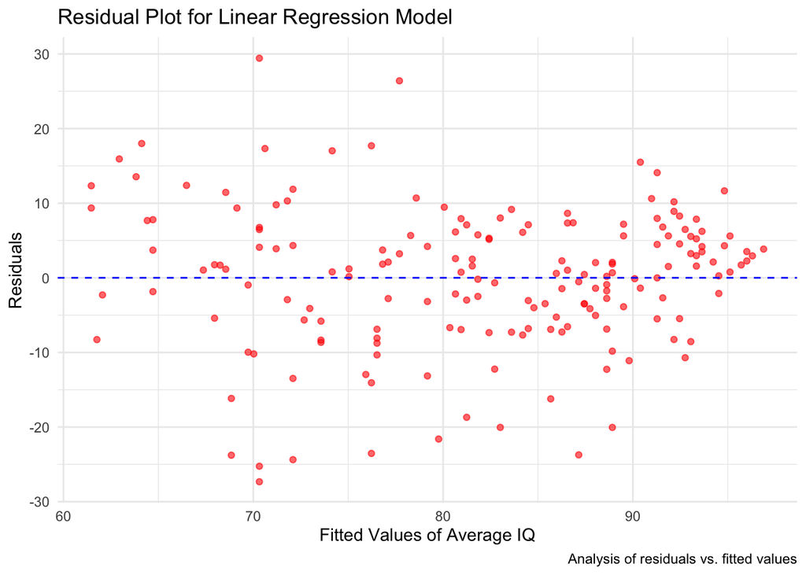

```r
model <- lm(Average.IQ ~ Mean.years.of.schooling...2021, data = cleaned_data)
residuals_df <- data.frame(Residuals = residuals(model), Fitted = fitted.values(model))

ggplot(residuals_df, aes(x = Fitted, y = Residuals)) +
  geom_point(alpha = 0.6, color = "red") +
  geom_hline(yintercept = 0, linetype = "dashed", color = "blue") +
  labs(title = "Residual Plot for Linear Regression Model",
       x = "Fitted Values of Average IQ",
       y = "Residuals",
       caption = "Analysis of residuals vs. fitted values") +
  theme_minimal()
```

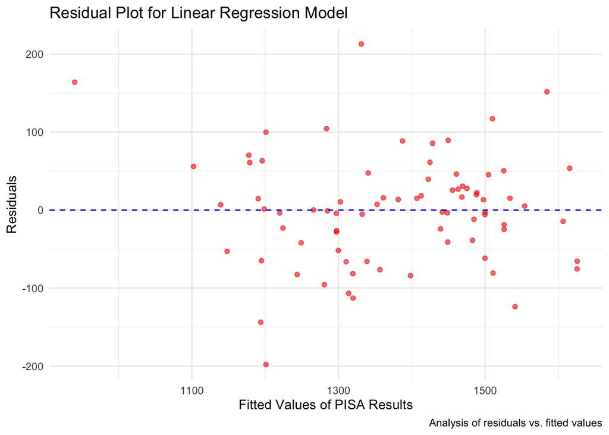

```r
model <- lm(Total.PISA.results...2018 ~ Average.IQ, data = clear_data)
residuals_df <- data.frame(Residuals = residuals(model), Fitted = fitted.values(model))

ggplot(residuals_df, aes(x = Fitted, y = Residuals)) +
  geom_point(alpha = 0.6, color = "red") +
  geom_hline(yintercept = 0, linetype = "dashed", color = "blue") +
  labs(title = "Residual Plot for Linear Regression Model",
       x = "Fitted Values of PISA Results",
       y = "Residuals",
       caption = "Analysis of residuals vs. fitted values") +
  theme_minimal()
```

For hypothesis testing:

```r
correlation <- cor(clear_data$Average.IQ, clear_data$Total.PISA.results...2018, use = "complete.obs")
cor.test(clear_data$Average.IQ, clear_data$Total.PISA.results...2018, method = "pearson")
```

```
##
##  Pearson's product-moment correlation
##
## data:  clear_data$Average.IQ and clear_data$Total.PISA.results...2018
## t = 17.565, df = 76, p-value < 2.2e-16
## alternative hypothesis: true correlation is not equal to 0
## 95 percent confidence interval:
##  0.8408186 0.9324183
## sample estimates:
##       cor
## 0.8957478
```

In conclusion:

- *Test Statistic (t = 17.565)*: A higher absolute value typically indicates a stronger evidence against the null hypothesis under the assumption that the null hypothesis is true.
- *P-value (< 2.2e-16)*: The p-value is much less than the conventional significance level of 0.05, which indicates that the null hypothesis were not true. Therefore, there is strong statistical evidence to reject the null hypothesis that there is no correlation between average IQ and PISA results.
- *Alternative Hypothesis*: The test result supports this hypothesis, suggesting that there is indeed a significant correlation between the variables.
- *Confidence Interval*: This interval estimates where the true correlation coefficient is likely to fall, with 95% confidence. The interval does not include zero and is well above zero, further supporting a strong positive correlation between average IQ and PISA results.
- *Sample Estimates (cor = 0.8957478)*: This is the estimated correlation coefficient between the two variables. This means as average IQ scores increase, PISA results also tend to increase, and this relationship is quite robust.

## 4.3 Limitations

Only half of the countries took part in the PISA assessment. IQ scores might contain cultural biases, or vary significantly depending on the methodologies used.